# Time Series Analysis - Assigment 2

Loan Huynh - s3655461

## Introduction

This report tries to find the suitable model which used to predict Egg deposition in next 5 years. The dataset is Egg depositions of age-3 Lake Huron Bloasters between 1981 and 1996 in **BloaterLH** dataset of **FSAdata** package

```r
library(forecast)
```

## Data Description

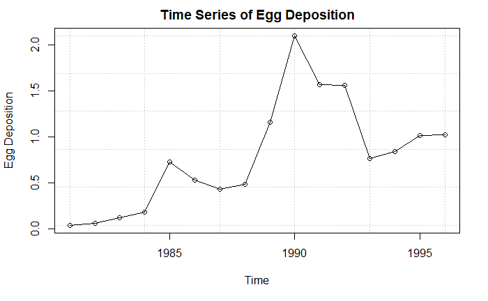

This series has an upward trend and changes of variation, but no repeating pattern in seasonality. There are some suceeding points but no fluctuation. It looks like the autoregressive

Using Scatter Plot to see the relationship between Egg Deposition of previous years

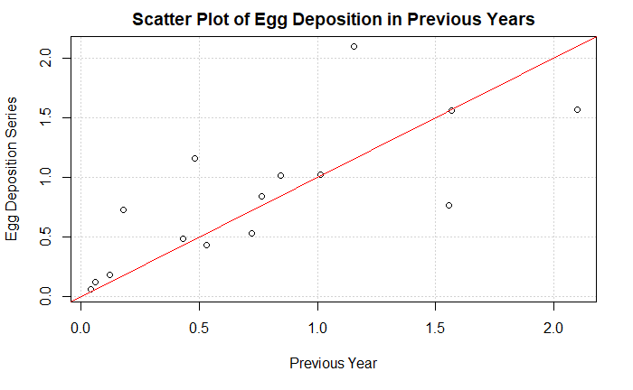

```r
# Scatter Plot
plot(y= egg_ts , x = zlag(egg_ts ), ylab = 'Egg Deposition Series', xlab =  'Previous Year',
     panel.first=grid(), main = "Scatter Plot of Egg Deposition in Previous Years")
abline(coef = c(0,1), col= "red")
```

It is obviously to see that there is a strong correlation between Egg Depositions of previous Years in Scatter Plot. The following code is to calculate the value of correlation

```r
y <- egg_ts # Load data into y
x <- zlag(egg_ts) # Generate first lag of the abundance series
index <- 2:length(x)# Create index to get rid of the first NA value in x
cor(y[index], x[index])# Calculate the correlation between numerical values in x and y
```

```
[1] 0.7445657
```

The correlation is 0.7445657. This is a strong positive correlation

Apply ADF Test to check whether series in stationary or non-stationary

```r
ar(diff(egg_ts))
```

```
Call:
ar(x = diff(egg_ts))


Order selected 0  sigma^2 estimated as  0.1841
```

Order of this test is 0

```r
adfTest(egg_ts, lags = 0) # ADF Test with an intercept and a time trend
```

```
Title:
 Augmented Dickey-Fuller Test

Test Results:
  PARAMETER:
    Lag Order: 0
  STATISTIC:
    Dickey-Fuller: -0.4911
  P VALUE:
    0.452

Description:
 Sun May 12 22:15:15 2019 by user: loanh
```

The p_value is 0.452 larger than 5% level of significant. Therefore we cannot reject null hypothesis about non-stationary. It implies that this series is non-stationary. It is clearly shown in ACF and PACF plots as below:

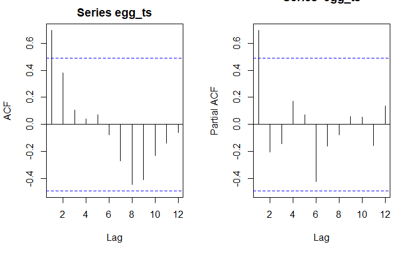

```r
par(mfrow=c(1,2))
acf(egg_ts)
pacf(egg_ts)
```

The ACF plot has pattern which has a large spike at lag 1 that decrease after a few lags

## DATA MODELING

#### DATA TRANSFORMATION AND DIFFERENCE

Apply Log transformation for this series

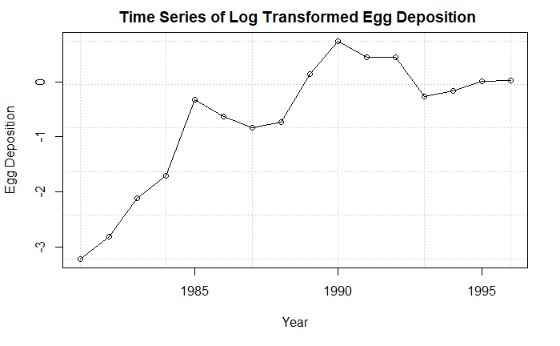

This series still has a trend.

Applying the first difference for transformed data

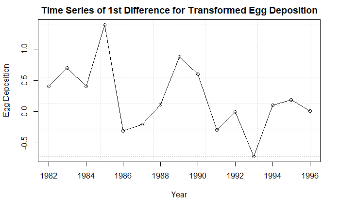

Applying ADF unit-root test to test the existence of non-stationary with this series

```r
ar(diff(diff.log.egg))
```

```
Call:
ar(x = diff(diff.log.egg))

Coefficients:
      1        2        3        4
-0.7962  -0.5984  -0.7310  -0.4869

Order selected 4  sigma^2 estimated as  0.3675
```

Order for this test is 4

```r
adfTest(diff.log.egg, lags = 4)
```

```
Title:
 Augmented Dickey-Fuller Test

Test Results:
  PARAMETER:
    Lag Order: 4
  STATISTIC:
    Dickey-Fuller: -1.2696
  P VALUE:
    0.2049

Description:
 Sun May 12 22:00:45 2019 by user: loanh
```

The p-value is 0.2049 larger than 5% level of significance. Therefore, this series is still non-stationary. Hence, we apply the second difference

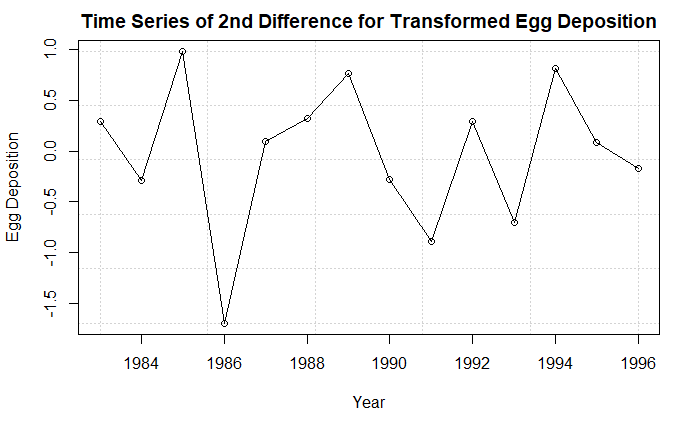

```r
diff2.log.egg <- diff(diff.log.egg, diference = 2)
plot(diff2.log.egg ,type='o',ylab='Egg Deposition', xlab= "Year", main = "Time Series of 2nd Difference for Transformed Egg Deposition",
     panel.first=grid())
```

Applying ADF unit-root test for second difference

```r
ar(diff(diff2.log.egg))
```

```
Call:
ar(x = diff(diff2.log.egg))

Coefficients:
      1
-0.6514

Order selected 1  sigma^2 estimated as  1.008
```

Order for this test is 1

```r
adfTest(diff2.log.egg, lags = 1)
```

```
p-value smaller than printed p-value
```

```
Title:
 Augmented Dickey-Fuller Test

Test Results:
  PARAMETER:
    Lag Order: 1
  STATISTIC:
    Dickey-Fuller: -3.167
  P VALUE:
    0.01

Description:
 Sun May 12 22:05:06 2019 by user: loanh
```

p-value = 0.01

The p-value equals 0.01 less than 5% level of signigicance. Therefore, we can reject null hypothesis for non-stationary. It means that this series is stationary.

Displaying ACF and PACF plots

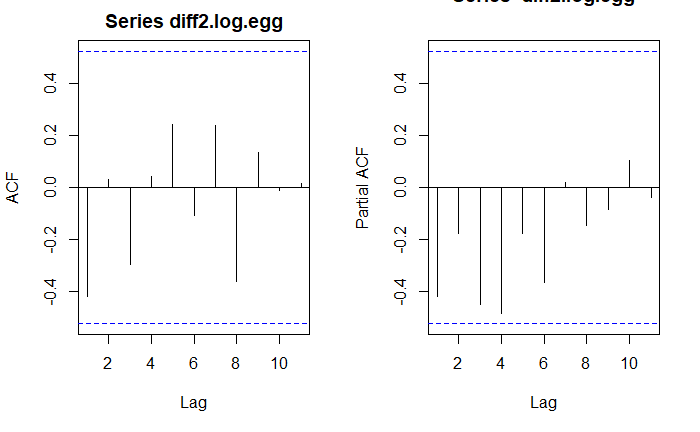

```r
par(mfrow=c(1,2))
acf(diff2.log.egg)
pacf(diff2.log.egg)
```

There is no pattern in ACF and PACF plots.

**Using EACF**

```r
# Applying EACF
eacf(diff2.log.egg, ar.max = 3, ma.max = 3)
```

```
AR/MA
  0 1 2 3
0 o o o o
1 o o o o
2 o o o o
3 o o o o
```

From the above matrix, the possible models are ARIMA(0,2,1), ARIMA(1,2,0), ARIMA(1,2,1)

**Using BIC table**

```r
# Using BIC table
res = armasubsets(y=diff2.log.egg,nar=3,nma=3,y.name='test',ar.method='ols')
```

[output not shown]

```
NaNs producedNaNs producedNaNs produced
```

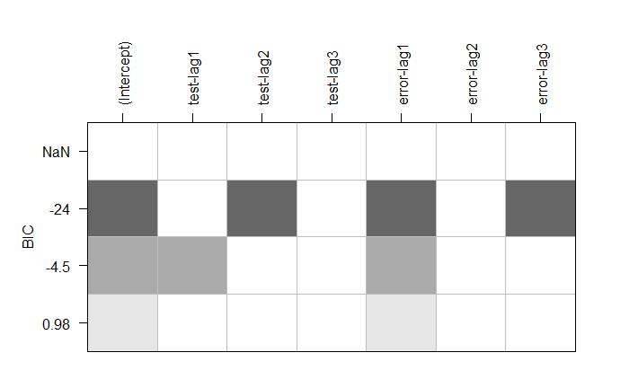

```r
plot(res)
```

From BIC table, possible models include ARIMA(2,2,1) , ARIMA(2,2,3) and ARIMA(1,2,1)

Hence the set of possible models will be {ARIMA(2,2,1), ARIMA(1,2,1), ARIMA(2,2,3), ARIMA(0,2,1), ARIMA(1,2,0), ARIMA(1,2,1)}

##### PARAMETER ESTIMATION

In order to estimate parameters of possible models, I use Maximum Likelihood method

**ARIMA(0,2,1)**

```r
model.021
```

```
Call:
arima(x = egg_ts, order = c(0, 2, 1), method = "ML")

Coefficients:
          ma1
      -1.0000
s.e.   0.2582

sigma^2 estimated as 0.1841:  log likelihood = -9.37,  aic = 20.75
```

```r
# Maximum likelihood estimates of the coefficients with significance tests for ARIMA(0,2,1) model
coeftest(model.021)
```

```
z test of coefficients:

    Estimate Std. Error z value  Pr(>|z|)
ma1 -1.00000    0.25823 -3.8725 0.0001077 ***
---
Signif. codes:  0 ‘***’ 0.001 ‘**’ 0.01 ‘*’ 0.05 ‘.’ 0.1 ‘ ’ 1
```

The p-value is less than 0.05. Therefore the estimated coefficients of ARIMA(0,2,1) model is significant

**ARIMA(2,2,1)**

```r
# Maximum likelihood estimates of the coefficients for ARIMA(2,2,1)
model.221 <- arima(egg_ts, order = c(2,2,1), method = 'ML')
model.221
```

```
Call:
arima(x = egg_ts, order = c(2, 2, 1), method = "ML")

Coefficients:
         ar1      ar2      ma1
      0.0711  -0.0106  -1.0000
s.e.  0.2694   0.2595   0.2397

sigma^2 estimated as 0.1846:  log likelihood = -9.34,  aic = 24.67
```

```r
coeftest(model.221)
```

```
z test of coefficients:

     Estimate Std. Error z value  Pr(>|z|)
ar1  0.071133   0.269440  0.2640    0.7918
ar2 -0.010595   0.259510 -0.0408    0.9674
ma1 -0.999992   0.239725 -4.1714 3.027e-05 ***
---
Signif. codes:  0 ‘***’ 0.001 ‘**’ 0.01 ‘*’ 0.05 ‘.’ 0.1 ‘ ’ 1
```

The estimated ar1 and ar2 coefficients are larger than 0.05. This means that they are are not significant

**ARIMA(1,2,1)**

```r
model.121
```

```
Call:
arima(x = egg_ts, order = c(1, 2, 1), method = "ML")

Coefficients:
         ar1      ma1
      0.0718  -1.0000
s.e.  0.2693   0.2369

sigma^2 estimated as 0.1849:  log likelihood = -9.34,  aic = 22.67
```

```r
# Maximum likelihood estimates of the coefficients with significance tests for ARIMA(1,2,1) model
coeftest(model.121)
```

```
z test of coefficients:

     Estimate Std. Error z value  Pr(>|z|)
ar1  0.071764   0.269251  0.2665    0.7898
ma1 -0.999999   0.236872 -4.2217 2.425e-05 ***
---
Signif. codes:  0 ‘***’ 0.001 ‘**’ 0.01 ‘*’ 0.05 ‘.’ 0.1 ‘ ’ 1
```

AR1 is insignificant in model ARIMA(1,2,1)

**ARIMA(2,2,3)**

```r
model.223 <- arima(egg_ts, order = c(2,2,3), method = 'ML')
coeftest(model.223)
```

```
z test of coefficients:

    Estimate Std. Error z value Pr(>|z|)
ar1 -0.58579    0.52391 -1.1181  0.26352
ar2 -0.38546    0.29026 -1.3280  0.18418
ma1 -0.13925    0.48815 -0.2853  0.77545
ma2  0.13920    0.49983  0.2785  0.78063
ma3 -0.99992    0.46140 -2.1671  0.03022 *
---
Signif. codes:  0 ‘***’ 0.001 ‘**’ 0.01 ‘*’ 0.05 ‘.’ 0.1 ‘ ’ 1
```

AR1, AR2, MA1 and MA2 are insignificant

**ARIMA(1,2,0)**

```r
model.120 <- arima(egg_ts, order = c(1,2,0), method = 'ML')
coeftest(model.120)
```

```
z test of coefficients:

    Estimate Std. Error z value Pr(>|z|)
ar1 -0.42966    0.22743 -1.8892  0.05886 .
---
Signif. codes:  0 ‘***’ 0.001 ‘**’ 0.01 ‘*’ 0.05 ‘.’ 0.1 ‘ ’ 1
```

AR1 is not significant as well in model ARIMA(1,2,0)

##### APPLYING AIC and BIC to decide the best model within the subset of possible models

__ AIC__

```r
AIC(model.021)
```

```
[1] 22.74602
```

```r
AIC(model.120)
```

```
[1] 26.57611
```

```r
AIC(model.121)
```

```
[1] 24.67428
```

```r
AIC(model.221)
```

```
[1] 26.67261
```

```r
AIC(model.223)
```

```
[1] 27.68002
```

**BIC**

```r
AIC(model.021, k = log(28))
```

```
[1] 25.41043
```

```r
AIC(model.121, k = log(28))
```

```
[1] 28.67089
```

```r
AIC(model.221, k = log(28))
```

```
[1] 32.00143
```

```r
AIC(model.223, k = log(28))
```

```
[1] 35.67324
```

The smallest AIC is model ARIMA(0,2,1) with 22.74602. According to BIC, model ARIMA(0,2,1) with value 25.41043 is the best. Therefore ARIMA(0,2,1) is the best model.

## MODEL DIAGNOTICS

**Normality Testing**

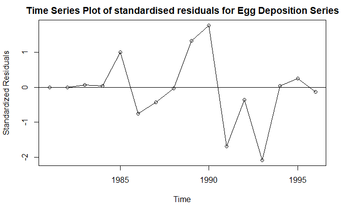

```r
plot(rstandard(model.021), type= 'o', ylab="Standardized Residuals", main = "Time Series Plot of standardised residuals for Egg Deposition Series")
abline(h=0)
```

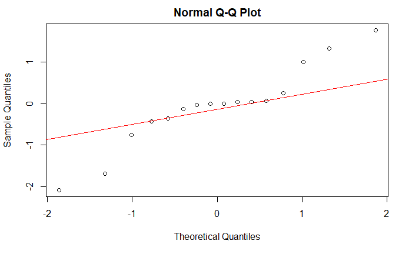

```r
qqnorm(rstandard(model.021))
qqline(rstandard(model.021), col = 2)
```

Most of values lie on the red line. However, there are still some outliers at the top right and left bottom

```r
# Using Shapiro test
shapiro.test(diff2.log.egg)
```

```
    Shapiro-Wilk normality test

data:  diff2.log.egg
W = 0.94806, p-value = 0.531
```

**AutoCorrelation of residuals testing**

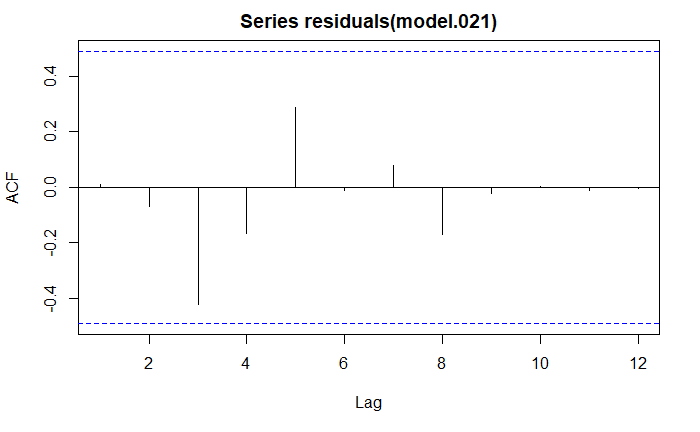

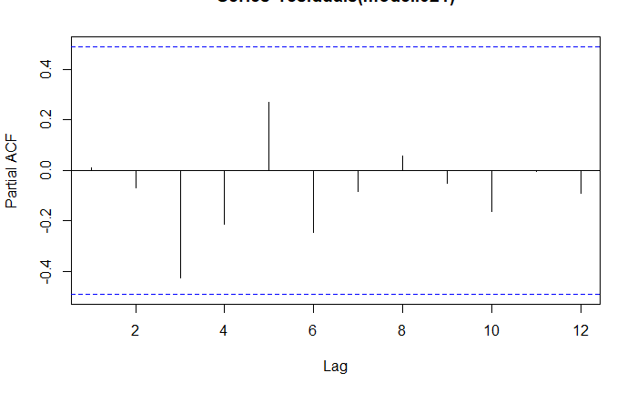

```r
pacf(residuals(model.021))
```

From ACF and PACF plots of residuals, we can conclude that the residuals constitutes a white noise series as there is no highly significant correlation.

```r
Box.test(residuals(model.021), lag = length(model.021$residuals) -1, type = "Box-Pierce", fitdf = 0)
```

```
    Box-Pierce test

data:  residuals(model.021)
X-squared = 5.3017, df = 15, p-value = 0.9892
```

In conclusion, there is no problem in the residuals of ARIMA(0,2,1) model.

## FORECASTING

```r
# Create a matrix of the covariance for prediction
xreg=data.frame (constant=seq(egg_ts))
n = length(egg_ts)
n.ahead = 5
newxreq = data.frame(constant = (n+1): (n+n.ahead))
predict(model.021, n.ahead = 5, newxreg = NULL, se.fit = TRUE)
```

```
$pred
Time Series:
Start = 1997
End = 2001
Frequency = 1
[1] 1.089693 1.155287 1.220880 1.286473 1.352067

$se
Time Series:
Start = 1997
End = 2001
Frequency = 1
[1] 0.4431333 0.6459723 0.8140879 0.9657867 1.1078333
```

The predict values of Egg depositions in next five years are {1.089693 ; 1.155287; 1.220880; 1.286473 ; 1.352067}

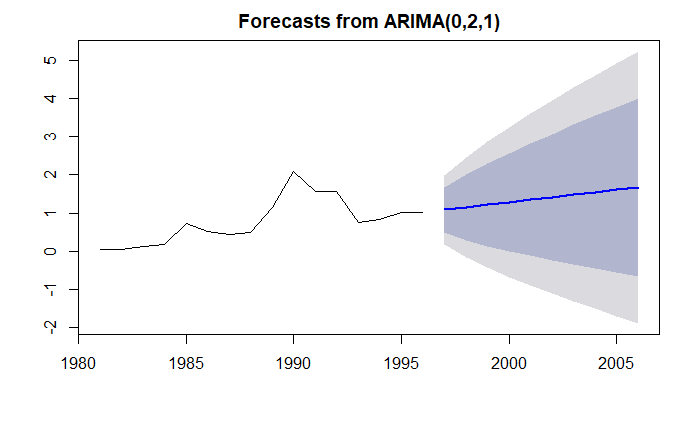

```r
#Plot forecasts over time series
fit = Arima(egg_ts,c(0,2,1))
plot(forecast(fit,h=10))
```